# 240 Midterm - practical part

The practical exam has five problems from the *Friends* data. We will revisit the earthquake data later in the course. There are five total questions worth 50 points.

You have two hours to complete the exam. Make sure to allow time to knit and upload. It is advisable to knit as you progress to ensure you do not have problems.

## Problem 1 (4 points)

The *Friends* data as you read it in as these columns:

- `text`: an “utterance” of words, typically spoken by one character before the next speaker begins speaking, with a few exceptions.
- `speaker`: the character who is speaking
  - Rows where `speaker` is “Scene Directions” do not contain dialogue, but instead describe non-verbal scene activity.
- `season`, `episode`, `scene`, `utterance`: seasons consist of multiple episodes; each episode consists of multiple scenes; and each scene has a sequence of utterances.

**Do the following:**

1. Import the data.
2. Use code to report the dimensions.
3. Eliminate rows where the `speaker` has the value “Scene Directions” and remove the `episode`, `scene`, and `utterance` columns.
4. Report the dimensions again.

```r
friends = read_csv("../../data/friends.csv")
dim(friends)
```

```
## [1] 67373     6
```

```r
speakers = friends %>%
  filter(speaker != "Scene Directions") %>%
  select(-episode, -scene, -utterance)
dim(speakers)
```

```
## [1] 61034     3
```

## Problem 2 (12 points)

A. Continuing with the data set from the previous problem:

1. Create a summary table with the twenty speakers who speak most frequently and the counts of their utterances, arranged from the highest to lowest values.
2. Print the full table. (This table should have two variables, `speaker` and `n`.)

The first six speakers in the arranged table are the primary characters of the show. Note that #7 on the list is `#ALL#`, used when all characters present say an utterance together.

```r
speaker_count = speakers %>%
  count(speaker) %>%
  arrange(desc(n)) %>%
  head(20)
speaker_count
```

```
## # A tibble: 20 × 2
##    speaker                    n
##    <chr>                  <int>
##  1 Rachel Green            9312
##  2 Ross Geller             9157
##  3 Chandler Bing           8465
##  4 Monica Geller           8441
##  5 Joey Tribbiani          8171
##  6 Phoebe Buffay           7501
##  7 #ALL#                    347
##  8 Mike Hannigan            330
##  9 Richard Burke            281
## 10 Janice Litman Goralnik   216
## 11 Carol Willick            193
## 12 Charlie Wheeler          189
## 13 Judy Geller              180
## 14 Frank Buffay Jr.         179
## 15 Emily Waltham            174
## 16 Jack Geller              150
## 17 Tag Jones                146
## 18 Gunther                  131
## 19 Amy Green                123
## 20 David                    120
```

B. The actor James Michael Tyler, who played Gunther on the show. died on October 24, 2021. He is sometimes referred to as the “7th friend” due to his frequent appearances on the show. (He appeared in more episodes than any character other than the six main characters.) Where does Gunther appear on the list of most common speakers?

Gunther is the 18th most common speaker in the show.

C. Create a vector with the names of the main characters.

1. Use code to create a vector named `main_characters` with the six main characters names by pulling the speaker names from this summary table. You will use this vector in the next two problems.
2. Print the vector with the character names.

```r
main_characters = head(speaker_count, 6)$speaker
main_characters
```

```
## [1] "Rachel Green"   "Ross Geller"    "Chandler Bing"  "Monica Geller"
## [5] "Joey Tribbiani" "Phoebe Buffay"
```

## Problem 3 (8 points)

1. Add a column named `main` to the `friends` data set from Problem 1 (you already removed scene directions) with the name of the speaker if the speaker is one of the six main characters and the value “Other” otherwise.
2. Calculate the proportion of all utterances spoken by each of the seven possible character labels (one of the six main characters or Other) and add these values in a column named `p`.
3. Arrange the rows from highest to lowest proportion.
4. Report this data in a table with seven rows and columns for `speaker`, the count of utterances `n`, and the proportion `p`.

```r
main_character_str = paste(main_characters, collapse="(?!.)|")
main = friends %>%
  mutate(
    main = case_when(
      str_detect(speaker, main_character_str) ~ speaker,
      TRUE ~ "Other"
    )
  )
main %>%
  count(main) %>%
  mutate(p = n/sum(n)) %>%
  arrange(desc(p))
```

```
## # A tibble: 7 × 3
##   main               n     p
##   <chr>          <int> <dbl>
## 1 Other          16326 0.242
## 2 Rachel Green    9312 0.138
## 3 Ross Geller     9157 0.136
## 4 Chandler Bing   8465 0.126
## 5 Monica Geller   8441 0.125
## 6 Joey Tribbiani  8171 0.121
## 7 Phoebe Buffay   7501 0.111
```

## Problem 4 (12 points)

Using the `friends` data set as modified in Problem 1:

1. Eliminate rows to keep only utterances by the six main characters.
2. Create a table that counts the number of utterances by each character and season.
3. Visualize these counts using a bar plot:
- with main character on the x axis;
- using a different fill color for each character; and
- a different facet for each season

You may add the layer in the R chunk below to your code for making the plot in order to eliminate the character names from the x axis tick labels and thus avoid overlapping labels. (The colors distinguish between the characters and legend will identify the characters.)

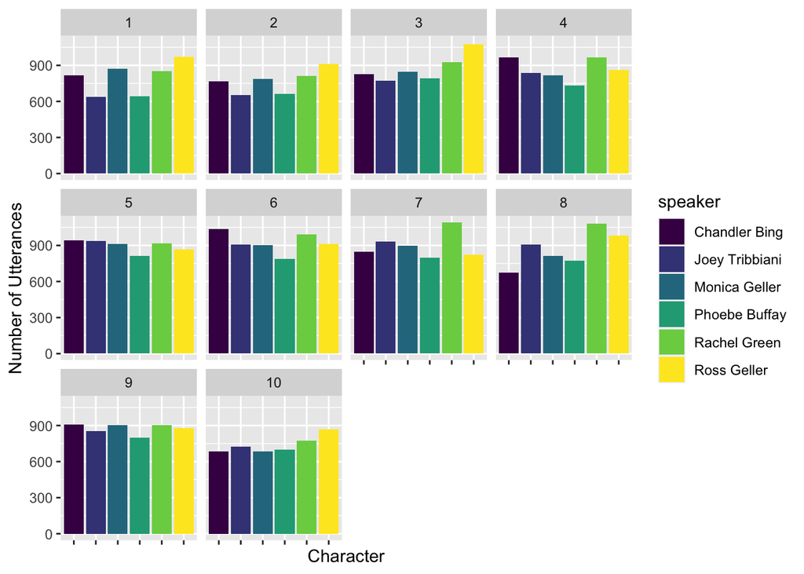

```r
speakers %>%
  filter(str_detect(speaker, main_character_str)) %>%
  count(speaker, season) %>%
  ggplot(aes(x=speaker, y=n, fill=speaker)) +
  geom_col() +
  facet_wrap(~ season) +
  scale_x_discrete(label = NULL) +
  labs(x="Character", y="Number of Utterances")
```

## Problem 5 (14 points)

Let’s do something interesting with the text. Specifically, let’s find out how many times characters refer to each other.

The next chunk of code creates six new *character counting columns* named after the six main characters’ first names. Each column records the number of times that character’s name appears in the text (i.e. how many times that name was said).

For example, in the third utterance of the series, Chandler Bing is the speaker and says,

> All right Joey, be nice. So does he have a hump? A hump and a hairpiece?

In the corresponding row of this modified data set, the column `joey.` has the value `1` as Chandler mentions Joey’s name, and the other character counting columns have value `0`. Rows will have all zeros in the character counting columns if no main character’s name was spoken.

```r
prob5 = friends %>%
  filter(speaker %in% main_characters) %>%
  mutate(ross. = str_count(text,"(?i)ross"),
         monica. = str_count(text,"(?i)monica"),
         rachel. = str_count(text,"(?i)rachel"),
         chandler. = str_count(text,"(?i)chandler"),
         phoebe. = str_count(text,"(?i)phoebe"),
         joey. = str_count(text,"(?i)joey")) %>%
  select(season, speaker, contains("."))

head(prob5)
```

```
## # A tibble: 6 × 8
##   season speaker        ross. monica. rachel. chandler. phoebe. joey.
##    <dbl> <chr>          <int>   <int>   <int>     <int>   <int> <int>
## 1      1 Monica Geller      0       0       0         0       0     0
## 2      1 Joey Tribbiani     0       0       0         0       0     0
## 3      1 Chandler Bing      0       0       0         0       0     1
## 4      1 Phoebe Buffay      0       0       0         0       0     0
## 5      1 Phoebe Buffay      0       0       0         0       0     0
## 6      1 Monica Geller      0       0       0         0       0     0
```

A. What does the regular expression `"(?i)"` do?

?i removes the need for case-sensitivity for string detection. Meaning all variations of a character’s name (e.g. joey, JOEY, etc.) will match the regular expression of simply “joey”.

B. Reshape the data in `prob5` into a long format:

- with one long column named `n` with the counts character counting columns
- with another column `name` with these column names
- retaining the columns named `season` and `speaker`.

If done properly, this data frame should look like what is below, and have over 300,000 rows as the data in each row in `prob5` has been split into six.

```
       season speaker       name          n
        <int> <chr>         <chr>     <int>
     1      1 Monica Geller ross.         0
     2      1 Monica Geller monica.       0
     3      1 Monica Geller rachel.       0
     4      1 Monica Geller chandler.     0
     5      1 Monica Geller phoebe.       0
     6      1 Monica Geller joey.         0
...
306281     10 Chandler Bing phoebe.       0
306282     10 Chandler Bing joey.         0
```

C. Then summarize this data table into a much smaller table where each `speaker` and `name` appear with a count `n` of the total number of times that the speaker referred to each character by name during the full series. This smaller table should have one row for each `speaker/name` pair. Piping this summary table into the provided command will rename the values of the `name` column to be the capitalized first name of the main character.

```r
# ... %>%
# mutate(name = str_to_title(str_sub(name, 1, -2)))
```

D. Make a bar plot with:

- a different facet for each speaker
- a different `x` value and fill color for each `name`

in order to display how often each main character refers to the others. You may again remove the names of the characters from the x axis to eliminate overlapping labels.

Which character refers to another character A LOT?